# Heart Failure Prediction Project on dataset (1000)

This heart disease dataset is acquired from one of the multispecialty hospitals in India. Over 14 common features make it one of the heart disease datasets available so far for research purposes. This dataset consists of 1000 subjects with 12 features. This dataset will be useful for building early-stage heart disease detection as well as for generating predictive machine-learning models.

https://www.kaggle.com/datasets/jocelyndumlao/cardiovascular-disease-dataset

```python
import warnings
# Ignore all warnings
warnings.filterwarnings('ignore')
```

```python
!pip install pandas
```

```python
import pandas as pd
data = pd.read_csv('hf_cardiovascular_disease_1000.csv')
```

```python
data.head()
```

|  | patientid | age | gender | chestpain | restingBP | serumcholestrol | fastingbloodsugar | restingrelectro | maxheartrate | exerciseangia | oldpeak | slope | noofmajorvessels | target |
| --- | --- | --- | --- | --- | --- | --- | --- | --- | --- | --- | --- | --- | --- | --- |
| 0 | 103368 | 53 | 1 | 2 | 171 | 0 | 0 | 1 | 147 | 0 | 5.3 | 3 | 3 | 1 |
| 1 | 119250 | 40 | 1 | 0 | 94 | 229 | 0 | 1 | 115 | 0 | 3.7 | 1 | 1 | 0 |
| 2 | 119372 | 49 | 1 | 2 | 133 | 142 | 0 | 0 | 202 | 1 | 5.0 | 1 | 0 | 0 |
| 3 | 132514 | 43 | 1 | 0 | 138 | 295 | 1 | 1 | 153 | 0 | 3.2 | 2 | 2 | 1 |
| 4 | 146211 | 31 | 1 | 1 | 199 | 0 | 0 | 2 | 136 | 0 | 5.3 | 3 | 2 | 1 |

```python
data.shape
```

```
(1000, 14)
```

```python
data.columns
```

```
Index(['patientid', 'age', 'gender', 'chestpain', 'restingBP',
       'serumcholestrol', 'fastingbloodsugar', 'restingrelectro',
       'maxheartrate', 'exerciseangia', 'oldpeak', 'slope', 'noofmajorvessels',
       'target'],
      dtype='object')
```

```python
data.isnull().sum()
```

```
patientid            0
age                  0
gender               0
chestpain            0
restingBP            0
serumcholestrol      0
fastingbloodsugar    0
restingrelectro      0
maxheartrate         0
exerciseangia        0
oldpeak              0
slope                0
noofmajorvessels     0
target               0
dtype: int64
```

```python
!pip install --upgrade scikit-learn
!pip install --upgrade imbalanced-learn
```

## Prepare and load the dataset

```python
import pandas as pd
from imblearn.over_sampling import SMOTE
from sklearn.model_selection import train_test_split
from sklearn.preprocessing import StandardScaler

# Load dataset
data = pd.read_csv('hf_cardiovascular_disease_1000.csv')

# fill missing values with mean values
data.fillna(data.mean(), inplace=True)

# Define features and target
X = data[['patientid', 'age', 'gender', 'chestpain', 'restingBP',
       'serumcholestrol', 'fastingbloodsugar', 'restingrelectro',
       'maxheartrate', 'exerciseangia', 'oldpeak', 'slope', 'noofmajorvessels']]
y = data['target']

# Apply SMOTE to balance the dataset
smote = SMOTE(random_state=42)
X_resampled, y_resampled = smote.fit_resample(X, y)

# Split data
X_train, X_test, y_train, y_test = train_test_split(X_resampled, y_resampled, test_size=0.2, random_state=42)

# Scale features
scaler = StandardScaler()
X_train = scaler.fit_transform(X_train)
X_test = scaler.transform(X_test)
```

```python
from sklearn.linear_model import LogisticRegression
from sklearn.metrics import classification_report, roc_auc_score, roc_curve
import matplotlib.pyplot as plt

# Logistic Regression with L2 regularization
lr = LogisticRegression(C=1.0, penalty='l2', solver='liblinear', random_state=42)
lr.fit(X_train, y_train)

# Predictions
y_pred_lr = lr.predict(X_test)
y_proba_lr = lr.predict_proba(X_test)[:, 1]

# Evaluation
print("Logistic Regression on dataset")
print(classification_report(y_test, y_pred_lr))
roc_auc_lr = roc_auc_score(y_test, y_proba_lr)
print(f'ROC AUC: {roc_auc_lr:.2f}')
```

```
Logistic Regression on dataset
              precision    recall  f1-score   support

           0       0.97      0.97      0.97       119
           1       0.96      0.96      0.96       113

    accuracy                           0.97       232
   macro avg       0.97      0.97      0.97       232
weighted avg       0.97      0.97      0.97       232

ROC AUC: 1.00
```

```python
from sklearn.model_selection import cross_val_score

# Perform cross-validation
cv_scores = cross_val_score(lr, X_train, y_train, cv=5, scoring='roc_auc')
print(f'Cross-Validation ROC AUC scores: {cv_scores}')
print(f'Mean ROC AUC score: {cv_scores.mean()}')
```

```
Cross-Validation ROC AUC scores: [0.9989593  0.98334875 0.99387212 0.99474053 0.99555867]
Mean ROC AUC score: 0.9932958754569329
```

```python
# Logistic Regression with increased regularization
lr = LogisticRegression(C=0.1, penalty='l2', solver='liblinear', random_state=42)
lr.fit(X_train, y_train)

# Predictions
y_pred_lr = lr.predict(X_test)
y_proba_lr = lr.predict_proba(X_test)[:, 1]

# Evaluation
print("Logistic Regression on dataset with increased regularization")
print(classification_report(y_test, y_pred_lr))
roc_auc_lr = roc_auc_score(y_test, y_proba_lr)
print(f'ROC AUC: {roc_auc_lr:.2f}')
```

```
Logistic Regression on dataset with increased regularization
              precision    recall  f1-score   support

           0       0.97      0.98      0.97       119
           1       0.98      0.96      0.97       113

    accuracy                           0.97       232
   macro avg       0.97      0.97      0.97       232
weighted avg       0.97      0.97      0.97       232

ROC AUC: 0.99
```

```python
from sklearn.feature_selection import RFE

# Feature selection using RFE
selector = RFE(lr, n_features_to_select=8, step=1)
selector = selector.fit(X_train, y_train)
X_train_rfe = selector.transform(X_train)
X_test_rfe = selector.transform(X_test)

# Train Logistic Regression on selected features
lr.fit(X_train_rfe, y_train)

# Predictions
y_pred_lr = lr.predict(X_test_rfe)
y_proba_lr = lr.predict_proba(X_test_rfe)[:, 1]

# Evaluation
print("Logistic Regression on dataset with feature selection")
print(classification_report(y_test, y_pred_lr))
roc_auc_lr = roc_auc_score(y_test, y_proba_lr)
print(f'ROC AUC: {roc_auc_lr:.2f}')
```

```
Logistic Regression on dataset with feature selection
              precision    recall  f1-score   support

           0       0.97      0.98      0.97       119
           1       0.98      0.96      0.97       113

    accuracy                           0.97       232
   macro avg       0.97      0.97      0.97       232
weighted avg       0.97      0.97      0.97       232

ROC AUC: 1.00
```

```
Bagging with Logistic Regression on dataset
              precision    recall  f1-score   support

           0       0.97      0.97      0.97       119
           1       0.96      0.96      0.96       113

    accuracy                           0.97       232
   macro avg       0.97      0.97      0.97       232
weighted avg       0.97      0.97      0.97       232

ROC AUC: 1.00
```

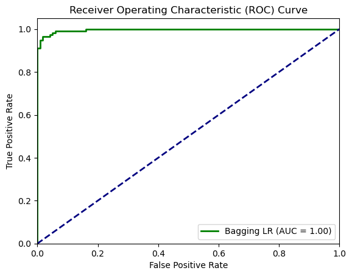

```python
from sklearn.ensemble import BaggingClassifier

# Bagging with Logistic Regression
bagging_lr = BaggingClassifier(estimator=LogisticRegression(C=1.0, penalty='l2', solver='liblinear', random_state=42),
                               n_estimators=10, random_state=42)
bagging_lr.fit(X_train, y_train)

# Predictions
y_pred_bagging_lr = bagging_lr.predict(X_test)
y_proba_bagging_lr = bagging_lr.predict_proba(X_test)[:, 1]

# Evaluation
print("Bagging with Logistic Regression on dataset")
print(classification_report(y_test, y_pred_bagging_lr))
roc_auc_bagging_lr = roc_auc_score(y_test, y_proba_bagging_lr)
print(f'ROC AUC: {roc_auc_bagging_lr:.2f}')

# Plot the ROC curve for Bagging Logistic Regression
fpr_bagging_lr, tpr_bagging_lr, _ = roc_curve(y_test, y_proba_bagging_lr)
plt.figure()
plt.plot(fpr_bagging_lr, tpr_bagging_lr, color='green', lw=2, label=f'Bagging LR (AUC = {roc_auc_bagging_lr:.2f})')
plt.plot([0, 1], [0, 1], color='navy', lw=2, linestyle='--')
plt.xlim([0.0, 1.0])
plt.ylim([0.0, 1.05])
plt.xlabel('False Positive Rate')
plt.ylabel('True Positive Rate')
plt.title('Receiver Operating Characteristic (ROC) Curve')
plt.legend(loc="lower right")
plt.show()
```

## Tuning parameters to mitigate the overfitting and underfitting issue

```
Logistic Regression on dataset with increased regularization
              precision    recall  f1-score   support

           0       0.81      0.76      0.78       119
           1       0.76      0.81      0.78       113

    accuracy                           0.78       232
   macro avg       0.79      0.79      0.78       232
weighted avg       0.79      0.78      0.78       232

ROC AUC: 0.85
Cross-Validation ROC AUC scores: [0.82296485 0.78769658 0.8627587  0.75467508 0.8385928 ]
Mean ROC AUC score: 0.8133376014445158
Best parameters for Logistic Regression: {'C': 1}
Logistic Regression with Hyperparameter Tuning on dataset
              precision    recall  f1-score   support

           0       0.80      0.76      0.78       119
           1       0.76      0.81      0.78       113

    accuracy                           0.78       232
   macro avg       0.78      0.78      0.78       232
weighted avg       0.78      0.78      0.78       232

ROC AUC: 0.85
Stacking Classifier on dataset
              precision    recall  f1-score   support

           0       0.84      0.82      0.83       119
           1       0.82      0.83      0.82       113

    accuracy                           0.83       232
   macro avg       0.83      0.83      0.83       232
weighted avg       0.83      0.83      0.83       232

ROC AUC: 0.93
```

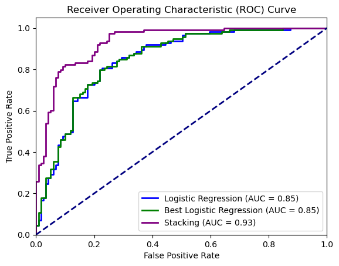

```python
import pandas as pd
from imblearn.over_sampling import SMOTE
from sklearn.model_selection import train_test_split, cross_val_score, GridSearchCV
from sklearn.preprocessing import StandardScaler
from sklearn.linear_model import LogisticRegression, RidgeClassifier, LassoCV
from sklearn.metrics import classification_report, roc_auc_score, roc_curve
import matplotlib.pyplot as plt
from sklearn.decomposition import PCA
from sklearn.ensemble import RandomForestClassifier, GradientBoostingClassifier, StackingClassifier
import numpy as np

# Load dataset
data = pd.read_csv('hf_cardiovascular_disease_1000.csv')

# Fill missing values with mean values
data.fillna(data.mean(), inplace=True)

# Define features and target
X = data[['patientid', 'age', 'gender', 'chestpain', 'restingBP',
       'serumcholestrol', 'fastingbloodsugar', 'restingrelectro',
       'maxheartrate', 'exerciseangia', 'oldpeak', 'slope', 'noofmajorvessels']]
y = data['target']

# Apply SMOTE to balance the dataset
smote = SMOTE(random_state=42)
X_resampled, y_resampled = smote.fit_resample(X, y)

# Dimensionality reduction using PCA
pca = PCA(n_components=5)
X_resampled_pca = pca.fit_transform(X_resampled)

# Split data
X_train, X_test, y_train, y_test = train_test_split(X_resampled_pca, y_resampled, test_size=0.2, random_state=42)

# Scale features
scaler = StandardScaler()
X_train = scaler.fit_transform(X_train)
X_test = scaler.transform(X_test)

# Logistic Regression with more aggressive regularization
lr = LogisticRegression(C=0.001, penalty='l2', solver='liblinear', random_state=42)
lr.fit(X_train, y_train)

# Predictions
y_pred_lr = lr.predict(X_test)
y_proba_lr = lr.predict_proba(X_test)[:, 1]

# Evaluation
print("Logistic Regression on dataset with increased regularization")
print(classification_report(y_test, y_pred_lr))
roc_auc_lr = roc_auc_score(y_test, y_proba_lr)
print(f'ROC AUC: {roc_auc_lr:.2f}')

# Cross-Validation
cv_scores = cross_val_score(lr, X_train, y_train, cv=5, scoring='roc_auc')
print(f'Cross-Validation ROC AUC scores: {cv_scores}')
print(f'Mean ROC AUC score: {cv_scores.mean()}')

# Hyperparameter Tuning for Logistic Regression
param_grid = {'C': [0.001, 0.01, 0.1, 1, 10]}
grid_search = GridSearchCV(LogisticRegression(penalty='l2', solver='liblinear', random_state=42), param_grid, cv=5, scoring='roc_auc')
grid_search.fit(X_train, y_train)

# Best parameters
best_params = grid_search.best_params_
print(f'Best parameters for Logistic Regression: {best_params}')

# Train Logistic Regression with best parameters
best_lr = grid_search.best_estimator_
best_lr.fit(X_train, y_train)

# Predictions
y_pred_best_lr = best_lr.predict(X_test)
y_proba_best_lr = best_lr.predict_proba(X_test)[:, 1]

# Evaluation
print("Logistic Regression with Hyperparameter Tuning on dataset")
print(classification_report(y_test, y_pred_best_lr))
roc_auc_best_lr = roc_auc_score(y_test, y_proba_best_lr)
print(f'ROC AUC: {roc_auc_best_lr:.2f}')

# Ensemble of Different Models
rf = RandomForestClassifier(n_estimators=50, random_state=42)
gb = GradientBoostingClassifier(n_estimators=50, random_state=42)

estimators = [
    ('lr', lr),
    ('rf', rf),
    ('gb', gb)
]

stacking_clf = StackingClassifier(estimators=estimators, final_estimator=LogisticRegression())

stacking_clf.fit(X_train, y_train)

# Predictions
y_pred_stacking = stacking_clf.predict(X_test)
y_proba_stacking = stacking_clf.predict_proba(X_test)[:, 1]

# Evaluation
print("Stacking Classifier on dataset")
print(classification_report(y_test, y_pred_stacking))
roc_auc_stacking = roc_auc_score(y_test, y_proba_stacking)
print(f'ROC AUC: {roc_auc_stacking:.2f}')

# Plot the ROC curves
plt.figure()
# Logistic Regression with increased regularization
fpr_lr, tpr_lr, _ = roc_curve(y_test, y_proba_lr)
plt.plot(fpr_lr, tpr_lr, color='blue', lw=2, label=f'Logistic Regression (AUC = {roc_auc_lr:.2f})')

# Logistic Regression with Hyperparameter Tuning
fpr_best_lr, tpr_best_lr, _ = roc_curve(y_test, y_proba_best_lr)
plt.plot(fpr_best_lr, tpr_best_lr, color='green', lw=2, label=f'Best Logistic Regression (AUC = {roc_auc_best_lr:.2f})')

# Stacking Classifier
fpr_stacking, tpr_stacking, _ = roc_curve(y_test, y_proba_stacking)
plt.plot(fpr_stacking, tpr_stacking, color='purple', lw=2, label=f'Stacking (AUC = {roc_auc_stacking:.2f})')

plt.plot([0, 1], [0, 1], color='navy', lw=2, linestyle='--')
plt.xlim([0.0, 1.0])
plt.ylim([0.0, 1.05])
plt.xlabel('False Positive Rate')
plt.ylabel('True Positive Rate')
plt.title('Receiver Operating Characteristic (ROC) Curve')
plt.legend(loc="lower right")
plt.show()
```

```
Logistic Regression on dataset with increased regularization
              precision    recall  f1-score   support

           0       0.81      0.76      0.78       119
           1       0.76      0.81      0.78       113

    accuracy                           0.78       232
   macro avg       0.79      0.79      0.78       232
weighted avg       0.79      0.78      0.78       232

ROC AUC: 0.85
Cross-Validation ROC AUC scores: [0.82296485 0.78769658 0.8627587  0.75467508 0.8385928 ]
Mean ROC AUC score: 0.8133376014445158
Best parameters for Logistic Regression: {'C': 1}
Logistic Regression with Hyperparameter Tuning on dataset 1000
              precision    recall  f1-score   support

           0       0.80      0.76      0.78       119
           1       0.76      0.81      0.78       113

    accuracy                           0.78       232
   macro avg       0.78      0.78      0.78       232
weighted avg       0.78      0.78      0.78       232

ROC AUC: 0.85
Stacking Classifier on dataset 1000
              precision    recall  f1-score   support

           0       0.84      0.82      0.83       119
           1       0.82      0.83      0.82       113

    accuracy                           0.83       232
   macro avg       0.83      0.83      0.83       232
weighted avg       0.83      0.83      0.83       232

ROC AUC: 0.93
```

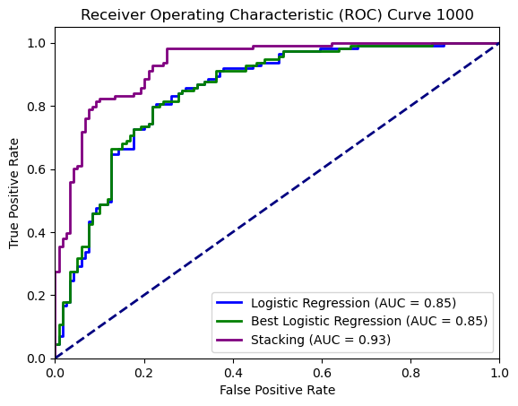

```python
import pandas as pd
from imblearn.over_sampling import SMOTE
from sklearn.model_selection import train_test_split, cross_val_score, GridSearchCV
from sklearn.preprocessing import StandardScaler
from sklearn.linear_model import LogisticRegression, RidgeClassifier, LassoCV
from sklearn.metrics import classification_report, roc_auc_score, roc_curve
import matplotlib.pyplot as plt
from sklearn.decomposition import PCA
from sklearn.ensemble import RandomForestClassifier, GradientBoostingClassifier, StackingClassifier, AdaBoostClassifier
import numpy as np

# Load dataset
data = pd.read_csv('hf_cardiovascular_disease_1000.csv')

# Fill missing values with mean values
data.fillna(data.mean(), inplace=True)

# Define features and target
X = data[['patientid', 'age', 'gender', 'chestpain', 'restingBP',
       'serumcholestrol', 'fastingbloodsugar', 'restingrelectro',
       'maxheartrate', 'exerciseangia', 'oldpeak', 'slope', 'noofmajorvessels']]
y = data['target']

# Apply SMOTE to balance the dataset
smote = SMOTE(random_state=42)
X_resampled, y_resampled = smote.fit_resample(X, y)

# Dimensionality reduction using PCA
pca = PCA(n_components=5)
X_resampled_pca = pca.fit_transform(X_resampled)

# Split data
X_train, X_test, y_train, y_test = train_test_split(X_resampled_pca, y_resampled, test_size=0.2, random_state=42)

# Scale features
scaler = StandardScaler()
X_train = scaler.fit_transform(X_train)
X_test = scaler.transform(X_test)

# Logistic Regression with more aggressive regularization
lr = LogisticRegression(C=0.001, penalty='l2', solver='liblinear', random_state=42)
lr.fit(X_train, y_train)

# Predictions
y_pred_lr = lr.predict(X_test)
y_proba_lr = lr.predict_proba(X_test)[:, 1]

# Evaluation
print("Logistic Regression on dataset with increased regularization")
print(classification_report(y_test, y_pred_lr))
roc_auc_lr = roc_auc_score(y_test, y_proba_lr)
print(f'ROC AUC: {roc_auc_lr:.2f}')

# Cross-Validation
cv_scores = cross_val_score(lr, X_train, y_train, cv=5, scoring='roc_auc')
print(f'Cross-Validation ROC AUC scores: {cv_scores}')
print(f'Mean ROC AUC score: {cv_scores.mean()}')

# Hyperparameter Tuning for Logistic Regression
param_grid = {'C': [0.001, 0.01, 0.1, 1, 10]}
grid_search = GridSearchCV(LogisticRegression(penalty='l2', solver='liblinear', random_state=42), param_grid, cv=5, scoring='roc_auc')
grid_search.fit(X_train, y_train)

# Best parameters
best_params = grid_search.best_params_
print(f'Best parameters for Logistic Regression: {best_params}')

# Train Logistic Regression with best parameters
best_lr = grid_search.best_estimator_
best_lr.fit(X_train, y_train)

# Predictions
y_pred_best_lr = best_lr.predict(X_test)
y_proba_best_lr = best_lr.predict_proba(X_test)[:, 1]

# Evaluation
print("Logistic Regression with Hyperparameter Tuning on dataset 1000")
print(classification_report(y_test, y_pred_best_lr))
roc_auc_best_lr = roc_auc_score(y_test, y_proba_best_lr)
print(f'ROC AUC: {roc_auc_best_lr:.2f}')

# Ensemble of Different Models
rf = RandomForestClassifier(n_estimators=50, random_state=42)
gb = GradientBoostingClassifier(n_estimators=50, random_state=42)
ada = AdaBoostClassifier(n_estimators=50, random_state=42)

estimators = [
    ('lr', lr),
    ('rf', rf),
    ('gb', gb),
    ('ada', ada)
]

stacking_clf = StackingClassifier(estimators=estimators, final_estimator=LogisticRegression())

stacking_clf.fit(X_train, y_train)

# Predictions
y_pred_stacking = stacking_clf.predict(X_test)
y_proba_stacking = stacking_clf.predict_proba(X_test)[:, 1]

# Evaluation
print("Stacking Classifier on dataset 1000")
print(classification_report(y_test, y_pred_stacking))
roc_auc_stacking = roc_auc_score(y_test, y_proba_stacking)
print(f'ROC AUC: {roc_auc_stacking:.2f}')

# Plot the ROC curves
plt.figure()
# Logistic Regression with increased regularization
fpr_lr, tpr_lr, _ = roc_curve(y_test, y_proba_lr)
plt.plot(fpr_lr, tpr_lr, color='blue', lw=2, label=f'Logistic Regression (AUC = {roc_auc_lr:.2f})')

# Logistic Regression with Hyperparameter Tuning
fpr_best_lr, tpr_best_lr, _ = roc_curve(y_test, y_proba_best_lr)
plt.plot(fpr_best_lr, tpr_best_lr, color='green', lw=2, label=f'Best Logistic Regression (AUC = {roc_auc_best_lr:.2f})')

# Stacking Classifier
fpr_stacking, tpr_stacking, _ = roc_curve(y_test, y_proba_stacking)
plt.plot(fpr_stacking, tpr_stacking, color='purple', lw=2, label=f'Stacking (AUC = {roc_auc_stacking:.2f})')

plt.plot([0, 1], [0, 1], color='navy', lw=2, linestyle='--')
plt.xlim([0.0, 1.0])
plt.ylim([0.0, 1.05])
plt.xlabel('False Positive Rate')
plt.ylabel('True Positive Rate')
plt.title('Receiver Operating Characteristic (ROC) Curve 1000')
plt.legend(loc="lower right")
plt.show()
```

1. Further Increased Regularization: Used a more aggressive regularization parameter for Logistic Regression.
2. Dimensionality Reduction: Applied PCA to reduce the number of features to 5.
3. Hyperparameter Tuning: Used Grid Search to find the best hyperparameters for Logistic Regression.
4. Additional Ensemble Model (AdaBoost): Added AdaBoost to the ensemble methods to enhance diversity and performance.
5. Evaluation and Comparison: Compared the performance of Logistic Regression with increased regularization, Logistic Regression with hyperparameter tuning, and Stacking Classifier.

These steps help further refine our model and improve its generalizability.

```python
from sklearn.svm import SVC

# Hyperparameter Tuning for SVM
param_grid = {'C': [0.1, 1, 10], 'kernel': ['linear', 'rbf', 'poly'], 'gamma': ['scale', 'auto']}
grid_search_svm = GridSearchCV(SVC(probability=True, random_state=42), param_grid, cv=5, scoring='roc_auc')
grid_search_svm.fit(X_train, y_train)

# Best parameters
best_params_svm = grid_search_svm.best_params_
print(f'Best parameters for SVM: {best_params_svm}')

# Train SVM with best parameters
best_svm = grid_search_svm.best_estimator_
best_svm.fit(X_train, y_train)

# Predictions
y_pred_best_svm = best_svm.predict(X_test)
y_proba_best_svm = best_svm.predict_proba(X_test)[:, 1]

# Evaluation
print("SVM with Hyperparameter Tuning on dataset 1000")
print(classification_report(y_test, y_pred_best_svm))
roc_auc_best_svm = roc_auc_score(y_test, y_proba_best_svm)
print(f'ROC AUC: {roc_auc_best_svm:.2f}')
```

```
Best parameters for SVM: {'C': 10, 'gamma': 'scale', 'kernel': 'rbf'}
SVM with Hyperparameter Tuning on dataset 1000
              precision    recall  f1-score   support

           0       0.86      0.85      0.85       119
           1       0.84      0.85      0.85       113

    accuracy                           0.85       232
   macro avg       0.85      0.85      0.85       232
weighted avg       0.85      0.85      0.85       232

ROC AUC: 0.89
```

```python
# Hyperparameter Tuning for Random Forest
param_grid = {'n_estimators': [50, 100, 200], 'max_depth': [3, 5, 10]}
grid_search_rf = GridSearchCV(RandomForestClassifier(random_state=42), param_grid, cv=5, scoring='roc_auc')
grid_search_rf.fit(X_train, y_train)

# Best parameters
best_params_rf = grid_search_rf.best_params_
print(f'Best parameters for RF: {best_params_rf}')

# Train RF with best parameters
best_rf = grid_search_rf.best_estimator_
best_rf.fit(X_train, y_train)

# Predictions
y_pred_best_rf = best_rf.predict(X_test)
y_proba_best_rf = best_rf.predict_proba(X_test)[:, 1]

# Evaluation
print("Random Forest with Hyperparameter Tuning on dataset 1000")
print(classification_report(y_test, y_pred_best_rf))
roc_auc_best_rf = roc_auc_score(y_test, y_proba_best_rf)
print(f'ROC AUC: {roc_auc_best_rf:.2f}')
```

```
Best parameters for RF: {'max_depth': 10, 'n_estimators': 200}
Random Forest with Hyperparameter Tuning on dataset 1000
              precision    recall  f1-score   support

           0       0.84      0.85      0.85       119
           1       0.84      0.83      0.84       113

    accuracy                           0.84       232
   macro avg       0.84      0.84      0.84       232
weighted avg       0.84      0.84      0.84       232

ROC AUC: 0.93
```

```python
# Hyperparameter Tuning for Gradient Boosting
param_grid = {'n_estimators': [50, 100, 200], 'learning_rate': [0.01, 0.1, 0.2], 'max_depth': [3, 5, 10]}
grid_search_gbm = GridSearchCV(GradientBoostingClassifier(random_state=42), param_grid, cv=5, scoring='roc_auc')
grid_search_gbm.fit(X_train, y_train)

# Best parameters
best_params_gbm = grid_search_gbm.best_params_
print(f'Best parameters for GBM: {best_params_gbm}')

# Train GBM with best parameters
best_gbm = grid_search_gbm.best_estimator_
best_gbm.fit(X_train, y_train)

# Predictions
y_pred_best_gbm = best_gbm.predict(X_test)
y_proba_best_gbm = best_gbm.predict_proba(X_test)[:, 1]

# Evaluation
print("Gradient Boosting with Hyperparameter Tuning on dataset 1000")
print(classification_report(y_test, y_pred_best_gbm))
roc_auc_best_gbm = roc_auc_score(y_test, y_proba_best_gbm)
print(f'ROC AUC: {roc_auc_best_gbm:.2f}')
```

```
Best parameters for GBM: {'learning_rate': 0.1, 'max_depth': 5, 'n_estimators': 200}
Gradient Boosting with Hyperparameter Tuning on dataset 1000
              precision    recall  f1-score   support

           0       0.86      0.85      0.86       119
           1       0.84      0.86      0.85       113

    accuracy                           0.85       232
   macro avg       0.85      0.85      0.85       232
weighted avg       0.85      0.85      0.85       232

ROC AUC: 0.92
```

```python
from xgboost import XGBClassifier

# Hyperparameter Tuning for XGBoost
param_grid = {'n_estimators': [50, 100, 200], 'learning_rate': [0.01, 0.1, 0.2], 'max_depth': [3, 5, 10]}
grid_search_xgbm = GridSearchCV(XGBClassifier(random_state=42), param_grid, cv=5, scoring='roc_auc')
grid_search_xgbm.fit(X_train, y_train)

# Best parameters
best_params_xgbm = grid_search_xgbm.best_params_
print(f'Best parameters for xGBM: {best_params_xgbm}')

# Train xGBM with best parameters
best_xgbm = grid_search_xgbm.best_estimator_
best_xgbm.fit(X_train, y_train)

# Predictions
y_pred_best_xgbm = best_xgbm.predict(X_test)
y_proba_best_xgbm = best_xgbm.predict_proba(X_test)[:, 1]

# Evaluation
print("XGBoost with Hyperparameter Tuning on dataset 1000")
print(classification_report(y_test, y_pred_best_xgbm))
roc_auc_best_xgbm = roc_auc_score(y_test, y_proba_best_xgbm)
print(f'ROC AUC: {roc_auc_best_xgbm:.2f}')
```

```
Best parameters for xGBM: {'learning_rate': 0.1, 'max_depth': 5, 'n_estimators': 50}
XGBoost with Hyperparameter Tuning on dataset 1000
              precision    recall  f1-score   support

           0       0.85      0.82      0.84       119
           1       0.82      0.85      0.83       113

    accuracy                           0.84       232
   macro avg       0.84      0.84      0.84       232
weighted avg       0.84      0.84      0.84       232

ROC AUC: 0.93
```

```python
# Simple Neural Network (NN)
import tensorflow as tf
from tensorflow.keras.models import Sequential
from tensorflow.keras.layers import Dense, Dropout

# Define input_dim based on your dataset
input_dim = X_train.shape[1]

# Simple Neural Network with hyperparameter tuning
model_nn = Sequential([
    Dense(64, activation='relu', input_shape=(input_dim,)),
    Dropout(0.5),
    Dense(32, activation='relu'),
    Dropout(0.5),
    Dense(1, activation='sigmoid')
])

model_nn.compile(optimizer='adam', loss='binary_crossentropy', metrics=['accuracy'])

# Train the model
model_nn.fit(X_train, y_train, epochs=50, batch_size=32, validation_split=0.2)

# Predictions
y_pred_nn = model_nn.predict(X_test).ravel()
y_pred_nn_class = (y_pred_nn > 0.5).astype(int)

# Evaluation
print("Simple Neural Network on dataset 1000")
print(classification_report(y_test, y_pred_nn_class))
roc_auc_nn = roc_auc_score(y_test, y_pred_nn)
print(f'ROC AUC: {roc_auc_nn:.2f}')
```

[output not shown]

[output cut: 21 more lines]

```python
# Convolutional Neural Network (CNN)
from tensorflow.keras.layers import Conv1D, MaxPooling1D, Flatten

# Reshape data to add timesteps dimension (e.g., timesteps=1)
X_train_cnn = X_train.reshape((X_train.shape[0], X_train.shape[1], 1))
X_test_cnn = X_test.reshape((X_test.shape[0], X_test.shape[1], 1))

# CNN Model
model_cnn = Sequential([
    Conv1D(32, kernel_size=3, activation='relu', input_shape=(input_dim, 1)),
    MaxPooling1D(pool_size=2),
    Dropout(0.5),
    Flatten(),
    Dense(64, activation='relu'),
    Dropout(0.5),
    Dense(1, activation='sigmoid')
])

model_cnn.compile(optimizer='adam', loss='binary_crossentropy', metrics=['accuracy'])

# Train the model
model_cnn.fit(X_train_cnn, y_train, epochs=50, batch_size=32, validation_split=0.2)

# Predictions
y_pred_cnn = model_cnn.predict(X_test_cnn).ravel()
y_pred_cnn_class = (y_pred_cnn > 0.5).astype(int)

# Evaluation
print("CNN on dataset 1000")
print(classification_report(y_test, y_pred_cnn_class))
roc_auc_cnn = roc_auc_score(y_test, y_pred_cnn)
print(f'ROC AUC: {roc_auc_cnn:.2f}')
```

[output not shown]

[output cut: 21 more lines]

```python
# GRU with Attention
from tensorflow.keras.layers import GRU, Attention, Input, Dense, Dropout
from tensorflow.keras.models import Model

# GRU with Attention
inputs = Input(shape=(input_dim, 1))
gru_out = GRU(32, return_sequences=True)(inputs)
attention_out = Attention()([gru_out, gru_out])
dropout_out = Dropout(0.5)(attention_out)
gru_out_2 = GRU(16)(dropout_out)
dropout_out_2 = Dropout(0.5)(gru_out_2)
outputs = Dense(1, activation='sigmoid')(dropout_out_2)

model_gru_attention = Model(inputs, outputs)
model_gru_attention.compile(optimizer='adam', loss='binary_crossentropy', metrics=['accuracy'])

# Train the model
model_gru_attention.fit(X_train_cnn, y_train, epochs=50, batch_size=32, validation_split=0.2)

# Predictions
y_pred_gru_attention = model_gru_attention.predict(X_test_cnn).ravel()
y_pred_gru_attention_class = (y_pred_gru_attention > 0.5).astype(int)

# Evaluation
print("GRU with Attention on dataset 1000")
print(classification_report(y_test, y_pred_gru_attention_class))
roc_auc_gru_attention = roc_auc_score(y_test, y_pred_gru_attention)
print(f'ROC AUC: {roc_auc_gru_attention:.2f}')
```

[output not shown]

[output cut: 21 more lines]

```python
# CNN with GRU
# CNN with GRU
model_cnn_gru = Sequential([
    Conv1D(32, kernel_size=3, activation='relu', input_shape=(input_dim, 1)),
    MaxPooling1D(pool_size=2),
    Dropout(0.5),
    GRU(32, return_sequences=True),
    Dropout(0.5),
    GRU(16),
    Dropout(0.5),
    Dense(1, activation='sigmoid')
])

model_cnn_gru.compile(optimizer='adam', loss='binary_crossentropy', metrics=['accuracy'])

# Train the model
model_cnn_gru.fit(X_train_cnn, y_train, epochs=50, batch_size=32, validation_split=0.2)

# Predictions
y_pred_cnn_gru = model_cnn_gru.predict(X_test_cnn).ravel()
y_pred_cnn_gru_class = (y_pred_cnn_gru > 0.5).astype(int)

# Evaluation
print("CNN with GRU on dataset 1000")
print(classification_report(y_test, y_pred_cnn_gru_class))
roc_auc_cnn_gru = roc_auc_score(y_test, y_pred_cnn_gru)
print(f'ROC AUC: {roc_auc_cnn_gru:.2f}')
```

[output not shown]

[output cut: 21 more lines]

## Stacking Model

```python
estimators = [
    ('rf', RandomForestClassifier(n_estimators=100, random_state=42)),
    ('gbm', GradientBoostingClassifier(n_estimators=100, random_state=42)),
    ('xgbm', XGBClassifier(n_estimators=100, random_state=42))
]

stacking_clf = StackingClassifier(estimators=estimators, final_estimator=LogisticRegression())

stacking_clf.fit(X_train, y_train)

# Predictions
y_pred_stacking = stacking_clf.predict(X_test)
y_proba_stacking = stacking_clf.predict_proba(X_test)[:, 1]

# Evaluation
print("Stacking Model (RF + GBM + xGBM) on dataset")
print(classification_report(y_test, y_pred_stacking))
roc_auc_stacking = roc_auc_score(y_test, y_proba_stacking)
print(f'ROC AUC: {roc_auc_stacking:.2f}')
```

```
Stacking Model (RF + GBM + xGBM) on dataset
              precision    recall  f1-score   support

           0       0.84      0.82      0.83       119
           1       0.82      0.84      0.83       113

    accuracy                           0.83       232
   macro avg       0.83      0.83      0.83       232
weighted avg       0.83      0.83      0.83       232

ROC AUC: 0.93
```

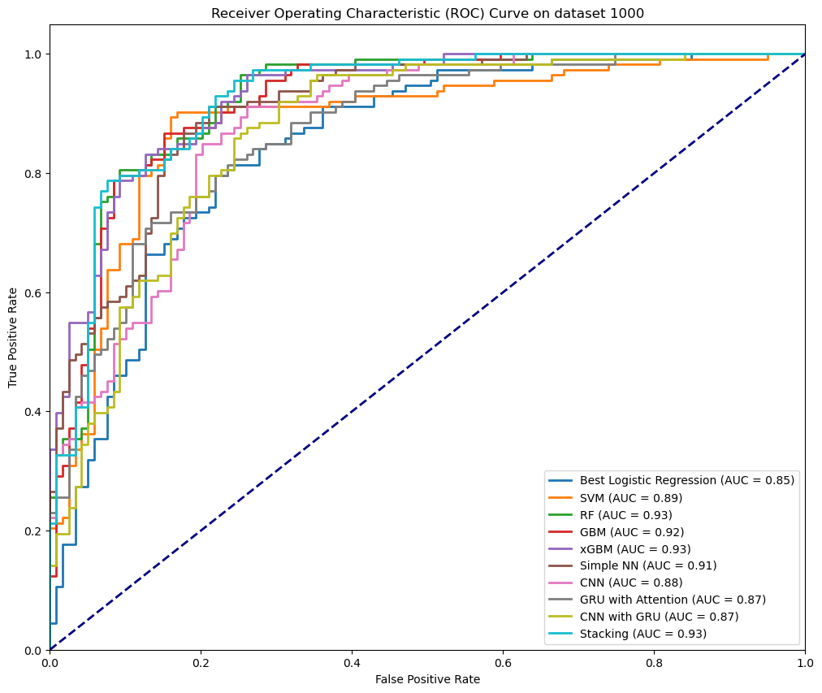

```python
## Summary and Evaluation
# Plot the ROC curves for all models
plt.figure(figsize=(12,10))

# Logistic Regression with Hyperparameter Tuning
fpr_best_lr, tpr_best_lr, _ = roc_curve(y_test, y_proba_best_lr)
plt.plot(fpr_best_lr, tpr_best_lr, lw=2, label=f'Best Logistic Regression (AUC = {roc_auc_best_lr:.2f})')

# SVM with Hyperparameter Tuning
fpr_best_svm, tpr_best_svm, _ = roc_curve(y_test, y_proba_best_svm)
plt.plot(fpr_best_svm, tpr_best_svm, lw=2, label=f'SVM (AUC = {roc_auc_best_svm:.2f})')

# Random Forest with Hyperparameter Tuning
fpr_best_rf, tpr_best_rf, _ = roc_curve(y_test, y_proba_best_rf)
plt.plot(fpr_best_rf, tpr_best_rf, lw=2, label=f'RF (AUC = {roc_auc_best_rf:.2f})')

# Gradient Boosting with Hyperparameter Tuning
fpr_best_gbm, tpr_best_gbm, _ = roc_curve(y_test, y_proba_best_gbm)
plt.plot(fpr_best_gbm, tpr_best_gbm, lw=2, label=f'GBM (AUC = {roc_auc_best_gbm:.2f})')

# XGBoost with Hyperparameter Tuning
fpr_best_xgbm, tpr_best_xgbm, _ = roc_curve(y_test, y_proba_best_xgbm)
plt.plot(fpr_best_xgbm, tpr_best_xgbm, lw=2, label=f'xGBM (AUC = {roc_auc_best_xgbm:.2f})')

# Simple Neural Network
fpr_nn, tpr_nn, _ = roc_curve(y_test, y_pred_nn)
plt.plot(fpr_nn, tpr_nn, lw=2, label=f'Simple NN (AUC = {roc_auc_nn:.2f})')

# CNN
fpr_cnn, tpr_cnn, _ = roc_curve(y_test, y_pred_cnn)
plt.plot(fpr_cnn, tpr_cnn, lw=2, label=f'CNN (AUC = {roc_auc_cnn:.2f})')

# GRU with Attention
fpr_gru_attention, tpr_gru_attention, _ = roc_curve(y_test, y_pred_gru_attention)
plt.plot(fpr_gru_attention, tpr_gru_attention, lw=2, label=f'GRU with Attention (AUC = {roc_auc_gru_attention:.2f})')

# CNN with GRU
fpr_cnn_gru, tpr_cnn_gru, _ = roc_curve(y_test, y_pred_cnn_gru)
plt.plot(fpr_cnn_gru, tpr_cnn_gru, lw=2, label=f'CNN with GRU (AUC = {roc_auc_cnn_gru:.2f})')

# Stacking Model
fpr_stacking, tpr_stacking, _ = roc_curve(y_test, y_proba_stacking)
plt.plot(fpr_stacking, tpr_stacking, lw=2, label=f'Stacking (AUC = {roc_auc_stacking:.2f})')

plt.plot([0, 1], [0, 1], color='navy', lw=2, linestyle='--')
plt.xlim([0.0, 1.0])
plt.ylim([0.0, 1.05])
plt.xlabel('False Positive Rate')
plt.ylabel('True Positive Rate')
plt.title('Receiver Operating Characteristic (ROC) Curve on dataset 1000')
plt.legend(loc="lower right")
plt.show()
```

```
29/29 ━━━━━━━━━━━━━━━━━━━━ 0s 283us/step
8/8 ━━━━━━━━━━━━━━━━━━━━ 0s 3ms/step
Stacking Model (RF + xGBM + CNN) on dataset
              precision    recall  f1-score   support

           0       0.85      0.83      0.84       119
           1       0.83      0.84      0.83       113

    accuracy                           0.84       232
   macro avg       0.84      0.84      0.84       232
weighted avg       0.84      0.84      0.84       232

ROC AUC: 0.92
```

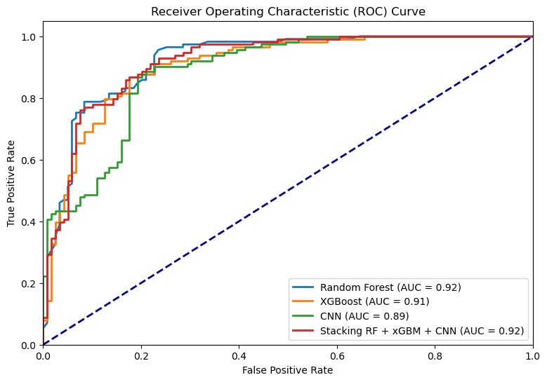

```python
import pandas as pd
from imblearn.over_sampling import SMOTE
from sklearn.model_selection import train_test_split, cross_val_score, GridSearchCV
from sklearn.preprocessing import StandardScaler
from sklearn.linear_model import LogisticRegression
from sklearn.metrics import classification_report, roc_auc_score, roc_curve
import matplotlib.pyplot as plt
from sklearn.decomposition import PCA
from sklearn.ensemble import RandomForestClassifier
from xgboost import XGBClassifier
import tensorflow as tf
from tensorflow.keras.models import Sequential
from tensorflow.keras.layers import Dense, Dropout, Conv1D, MaxPooling1D, Flatten
from sklearn.base import BaseEstimator, ClassifierMixin
import numpy as np

# Custom KerasClassifier wrapper
class CustomKerasClassifier(BaseEstimator, ClassifierMixin):
    def __init__(self, build_fn=None, epochs=1, batch_size=32, verbose=0):
        self.build_fn = build_fn
        self.epochs = epochs
        self.batch_size = batch_size
        self.verbose = verbose
        self.model = None

    def fit(self, X, y):
        self.model = self.build_fn()
        self.model.fit(X, y, epochs=self.epochs, batch_size=self.batch_size, verbose=self.verbose)
        return self

    def predict(self, X):
        return (self.model.predict(X) > 0.5).astype(int).ravel()

    def predict_proba(self, X):
        proba = self.model.predict(X)
        return np.hstack([(1 - proba), proba])

# Load dataset
data = pd.read_csv('hf_cardiovascular_disease_1000.csv')

# Fill missing values with mean values
data.fillna(data.mean(), inplace=True)

# Define features and target
X = data[['patientid', 'age', 'gender', 'chestpain', 'restingBP',
       'serumcholestrol', 'fastingbloodsugar', 'restingrelectro',
       'maxheartrate', 'exerciseangia', 'oldpeak', 'slope', 'noofmajorvessels']]
y = data['target']

# Apply SMOTE to balance the dataset
smote = SMOTE(random_state=42)
X_resampled, y_resampled = smote.fit_resample(X, y)

# Dimensionality reduction using PCA
pca = PCA(n_components=5)
X_resampled_pca = pca.fit_transform(X_resampled)

# Split data
X_train, X_test, y_train, y_test = train_test_split(X_resampled_pca, y_resampled, test_size=0.2, random_state=42)

# Scale features
scaler = StandardScaler()
X_train = scaler.fit_transform(X_train)
X_test = scaler.transform(X_test)

# Define the CNN model function
def create_cnn():
    model = Sequential([
        Conv1D(32, kernel_size=3, activation='relu', input_shape=(5, 1)),
        MaxPooling1D(pool_size=2),
        Dropout(0.5),
        Flatten(),
        Dense(64, activation='relu'),
        Dropout(0.5),
        Dense(1, activation='sigmoid')
    ])
    model.compile(optimizer='adam', loss='binary_crossentropy', metrics=['accuracy'])
    return model

# Reshape data for CNN
X_train_cnn = X_train.reshape((X_train.shape[0], X_train.shape[1], 1))
X_test_cnn = X_test.reshape((X_test.shape[0], X_test.shape[1], 1))

# Custom KerasClassifier wrapper
cnn = CustomKerasClassifier(build_fn=create_cnn, epochs=50, batch_size=32)

# Fit the CNN model first (necessary for stacking)
cnn.fit(X_train_cnn, y_train)

# Define other models
rf = RandomForestClassifier(n_estimators=100, random_state=42)
xgbm = XGBClassifier(n_estimators=100, random_state=42)

# Fit RF and xGBM
rf.fit(X_train, y_train)
xgbm.fit(X_train, y_train)

# Predictions for stacking
y_pred_rf = rf.predict_proba(X_train)[:, 1]
y_pred_xgbm = xgbm.predict_proba(X_train)[:, 1]
y_pred_cnn = cnn.predict_proba(X_train_cnn)[:, 1]

# Combine predictions as new features for the final model
X_train_meta = np.column_stack((y_pred_rf, y_pred_xgbm, y_pred_cnn))

# Train the final meta-model
meta_model = LogisticRegression()
meta_model.fit(X_train_meta, y_train)

# Predictions on the test set
y_pred_rf_test = rf.predict_proba(X_test)[:, 1]
y_pred_xgbm_test = xgbm.predict_proba(X_test)[:, 1]
y_pred_cnn_test = cnn.predict_proba(X_test_cnn)[:, 1]

# Combine predictions as new features for the test set
X_test_meta = np.column_stack((y_pred_rf_test, y_pred_xgbm_test, y_pred_cnn_test))

# Final predictions
y_pred_meta = meta_model.predict(X_test_meta)
y_proba_meta = meta_model.predict_proba(X_test_meta)[:, 1]

# Evaluation
print("Stacking Model (RF + xGBM + CNN) on dataset")
print(classification_report(y_test, y_pred_meta))
roc_auc_meta = roc_auc_score(y_test, y_proba_meta)
print(f'ROC AUC: {roc_auc_meta:.2f}')

# Plot the ROC curves for all models including the new stacking model
plt.figure(figsize=(9, 6))

# Plotting the ROC curves for each individual model
fpr_rf, tpr_rf, _ = roc_curve(y_test, y_pred_rf_test)
plt.plot(fpr_rf, tpr_rf, lw=2, label=f'Random Forest (AUC = {roc_auc_score(y_test, y_pred_rf_test):.2f})')

fpr_xgbm, tpr_xgbm, _ = roc_curve(y_test, y_pred_xgbm_test)
plt.plot(fpr_xgbm, tpr_xgbm, lw=2, label=f'XGBoost (AUC = {roc_auc_score(y_test, y_pred_xgbm_test):.2f})')

fpr_cnn, tpr_cnn, _ = roc_curve(y_test, y_pred_cnn_test)
plt.plot(fpr_cnn, tpr_cnn, lw=2, label=f'CNN (AUC = {roc_auc_score(y_test, y_pred_cnn_test):.2f})')

# Plotting the ROC curve for the stacking model
fpr_stacking, tpr_stacking, _ = roc_curve(y_test, y_proba_meta)
plt.plot(fpr_stacking, tpr_stacking, lw=2, label=f'Stacking RF + xGBM + CNN (AUC = {roc_auc_meta:.2f})')

plt.plot([0, 1], [0, 1], color='navy', lw=2, linestyle='--')
plt.xlim([0.0, 1.0])
plt.ylim([0.0, 1.05])
plt.xlabel('False Positive Rate')
plt.ylabel('True Positive Rate')
plt.title('Receiver Operating Characteristic (ROC) Curve')
plt.legend(loc="lower right")
plt.show()
```